```python
%matplotlib inline
```

# Contoh model Logistic Regression untuk task Klasifikasi

Di dokumen ini akan di bahas langkah-langkah untuk membuat model menggunakan algoritma atau metode logistic regression. Mulai dari training data sampai visualisasi model yang telah kita buat.

Di asumsikan pembaca sudah familiar dengan konsep dasar machine learning. Bagi para peserta [program mentoring](https://artificialintelligence.id/ai-indonesia-academy-batch-1-3507d130e187) yang sudah mendapatkan dan memahami konsep dasar machine learning di rekomendasikan untuk membaca catatan ini.

Pertama-tama kita import beberapa python packages yang kita gunakan.

`numpy` untuk membuat array dengan nilai acak. Kita juga akan menggunakan model linear yang ada di `scikit-learn` dan membuat train/test data secara acak.

```python
import numpy as np
from sklearn import linear_model, datasets
```

`matplotlib` kita gunakan untuk visualisasi training data, test data dan model yang kita buat

```python
import matplotlib.pyplot as plt
```

## Langkah 1: Data

Sebagai contoh saja, kita akan membuat datanya secara acak.

Dalam prakteknya, data bisa berupa nilai khusus seperti harga produk, ukuran dan lain-lain. Biasanya juga berbentuk raw teks atau gambar yang kemudian di representasikan sebagai vektor.

Untuk representasi data dari raw teks ke vektor akan di bahas lebih lengkap saat sesi feature engineering, sesuai dengan [studi kasus](https://artificialintelligence.id/model-machine-learning-untuk-membantu-pak-presiden-jokowi-menganalisa-respon-publik-63cc89a098ed) yang kita bahas di program mentoring.

Untuk sekarang kita cuma memakai 2 feature aja supaya mudah di plot di bidang 2D. Kita rasa klasifikasi 4 class aja cukup. Dalam prakteknya jumlah feature bisa lebih dari 60 ribu dimensi, sehingga sangat sulit untuk di bayangkan secara visual.

```python
data = datasets.make_classification(n_samples=100, n_features=2,
    n_informative=2, n_redundant=0, n_classes=4, n_clusters_per_class=1)
```

Untuk keperluan grafik, akan kita simpan nilai `x {max,min}` dan `y {max,min}` dari data yang kita generate secara acak

```python
x_min, x_max = data[0][:, 0].min() - .5, data[0][:, 0].max() + .5
y_min, y_max = data[0][:, 1].min() - .5, data[0][:, 1].max() + .5
```

Kita split data yang kita peroleh 80% untuk train dan 20% untuk test.

```python
train_input = data[0][:80]
train_output = data[1][:80]
test_input = data[0][-20:]
test_output = data[1][-20:]
```

`train_input` berupa array berukuran 80x2. Dengan 80 adalah jumlah sample data kita dan 2 adalah jumlah features.

```python
print train_input
```

```
[[ 1.39859607  0.43267215]
 [-0.87719749  1.83063007]
 [-0.87921343 -0.21015222]
 [ 1.23629838 -1.38236779]
 [ 0.76382906  1.32807133]
 [-0.78508625 -0.10137959]
 [ 1.69805962 -0.49156922]
 [ 0.69184651  1.52825662]
 [ 0.20929998  1.81489792]
 [ 0.96359318  0.88439886]
 [-1.13551844  1.20507029]
 [-0.12429491 -0.78092574]
 [ 0.49659     2.32963978]
 [-1.33085101 -0.94442291]
 [-0.45187625 -0.89529201]
 [-1.03887327 -0.98312908]
 [-0.94223612 -0.93982291]
 [-0.94470228  1.75073331]
 [ 0.89785815 -1.50204874]
 [-0.08332187 -1.58875679]
 [-0.45962546 -1.02268451]
 [-1.69219001 -1.29508676]
 [ 1.55897093 -0.10399234]
 [ 1.24137613 -0.83661355]
 [ 0.83754    -0.88610842]
 [ 1.34984316  0.78264358]
 [ 0.34838263 -0.97207557]
 [ 0.07477    -2.41221573]
 [ 1.5329842  -1.16308578]
 [ 0.56508948  1.84570939]
 [-0.89195059 -1.01465545]
 [-1.03107641 -0.91293173]
 [-0.30463991 -1.8997782 ]
 [ 0.79257175  1.11536079]
 [-0.93101303  0.24661022]
 [ 1.27418764 -0.6530478 ]
 [ 0.83277979 -0.66759758]
 [-1.78775405 -0.92862236]
 [-1.24771528 -1.0046961 ]
 [-0.96258071  0.19690784]
```

[output cut: 25 more lines]

```
 [-0.64067163 -1.15412548]
 [-0.83059001  0.62953187]
 [-0.53011054 -0.8991897 ]
 [ 0.78192852  1.18222869]
 [-1.66802916 -1.13237104]
 [ 1.30783703  0.48491871]
 [-1.07503909  0.8805824 ]
 [-1.44413953 -0.84057267]
 [-1.02548345  1.46344147]
 [ 0.83302677  1.48755839]
 [-0.02994092  1.65424535]
 [-0.83253692  0.0936721 ]
 [-1.0121191   1.2983503 ]
 [ 0.79198326  1.0578813 ]
 [-0.50835271  3.1914717 ]]
```

`train_output` merupakan array ukuran 1x80 yang menandakan label (jenis class) tiap sample yang ada di `train_input`

```python
print train_output
```

```
[3 2 2 1 3 2 1 3 3 3 2 0 3 0 0 0 0 2 1 1 0 0 1 1 1 3 0 1 1 3 0 0 1 3 2 1 1
 0 0 2 1 3 0 3 2 1 0 1 2 1 3 2 2 0 1 1 1 3 0 2 3 2 3 2 2 0 2 0 3 0 3 2 0 2
 3 3 2 2 3 3]
```

Kita akan coba visualisasikan training datanya ke dalam bidang 2D

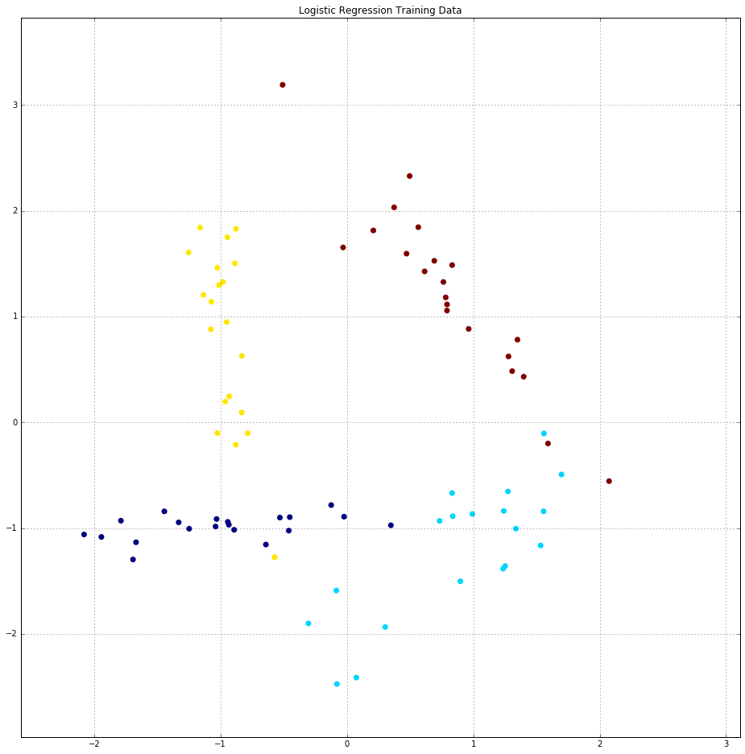

```python
plt.figure(1, figsize=(16, 16))
plt.title('Logistic Regression Training Data')
plt.scatter(train_input[:, 0], train_input[:, 1], c=train_output, edgecolors='none',s=50)
plt.xlim(x_min, x_max)
plt.ylim(y_min, y_max)
plt.grid(True)
plt.show()
```

Titik-titk di gambar tersebut mewakili satu object yang ingin kita klasifikasikan, misal sebuah teks berita online, deskripsi produk, gambar produk dan lain-lain.

Setiap satu object masuk dalam satu class. Tiap class memiliki warna yang berbeda dengan class yang lainnya.

Intuisi dari pembuatan model ini adalah kita ingin mencari garis pemisah atau area yang meliputi tiap kelas yang berbeda. Sehingga, ketika ada data baru atau titik baru yang belum diketahui kelasnya, kita akan coba memprediksi titik tersebut masuk class mana. Penentuan class titik baru ini sesuai dengan model yang sudah kita buat.

## Langkah 2: Algoritma Machine Learning

Dalam contoh ini, kita akan menggunakan Logistic regression.

```python
logreg = linear_model.LogisticRegression()
```

## Langkah 3: Model

Model akan dibuat berdasarkan `train_{input,output}` data

```python
logreg.fit(train_input, train_output)
```

```
LogisticRegression(C=1.0, class_weight=None, dual=False, fit_intercept=True,
          intercept_scaling=1, max_iter=100, multi_class='ovr', n_jobs=1,
          penalty='l2', random_state=None, solver='liblinear', tol=0.0001,
          verbose=0, warm_start=False)
```

Kita akan coba mengvisualisasikan model yang kita dapat di bidang 2D

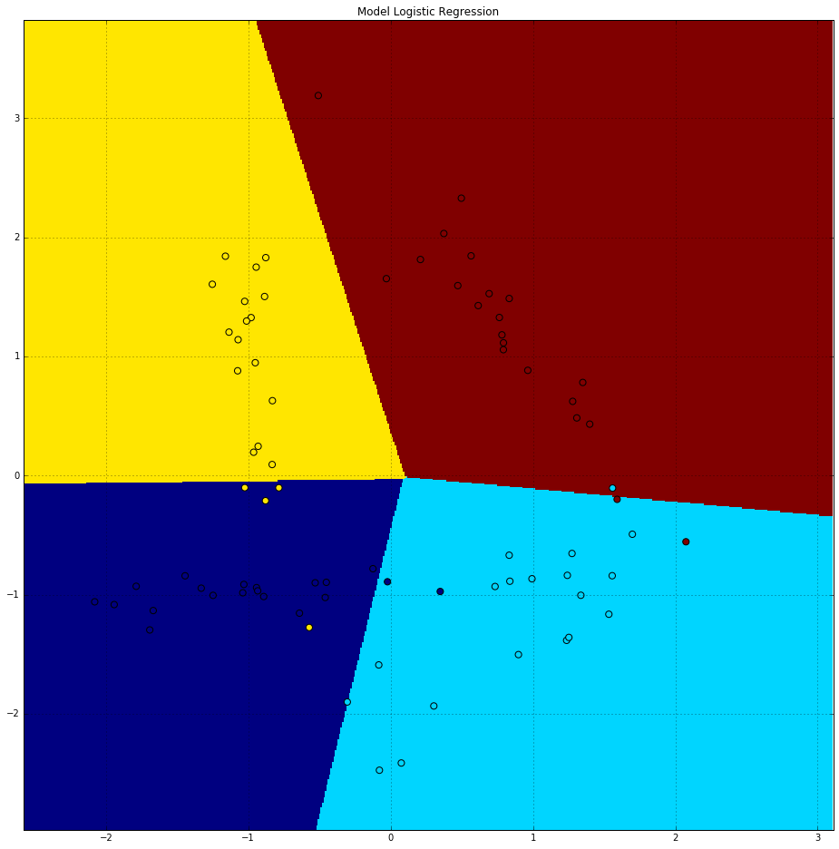

```python
h = .01 # nilai tambah untuk tiap iterasi di meshgrid
xx, yy = np.meshgrid(np.arange(x_min, x_max, h), np.arange(y_min, y_max, h))
Z = logreg.predict(np.c_[xx.ravel(), yy.ravel()])
Z = Z.reshape(xx.shape)

plt.figure(2, figsize=(16, 16))
plt.title('Model Logistic Regression')
plt.pcolormesh(xx, yy, Z)
plt.scatter(train_input[:, 0], train_input[:, 1], c=train_output, edgecolors='k',s=50)
plt.xlim(x_min, x_max)
plt.ylim(y_min, y_max)
plt.grid(True)
plt.show()
```

Gambar diatas merepresentasikan model pertama kita, cukup bagus lah ya untuk 100 iterasi. Ada beberapa object yang overlap, dan inilah kelemahan model linear seperti logistic regression.

Kita bisa memperbaiki model dengan meningkatkan jumlah iterasi, memperkecil toleransi dan lain-lain. Istilahnya adalah tune-in model.

Mari kita lihat model dan test data kita.

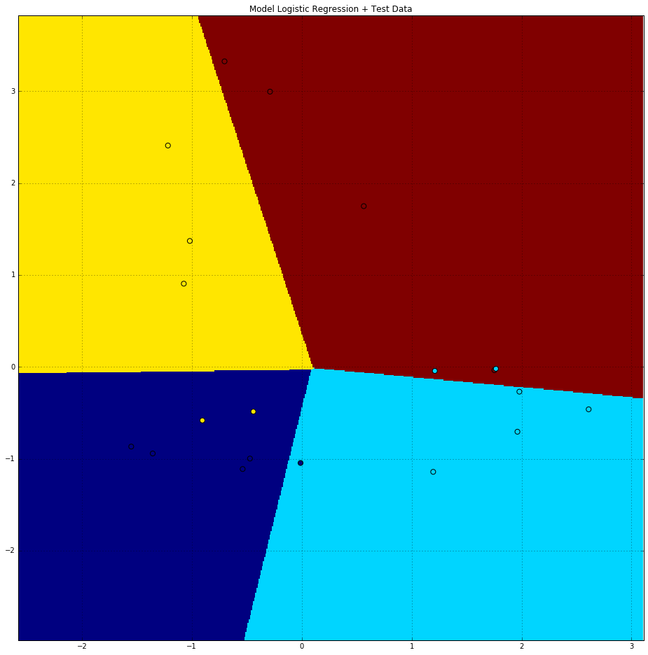

```python
plt.figure(3, figsize=(16, 16))
plt.title('Model Logistic Regression + Test Data')
plt.pcolormesh(xx, yy, Z)
plt.scatter(test_input[:, 0], test_input[:, 1], c=test_output, edgecolors='k',s=50)
plt.xlim(x_min, x_max)
plt.ylim(y_min, y_max)
plt.grid(True)
plt.show()
```

hmmm, lumayan lah ya.

Anyway, kita udah dapet nih intuisi dasar machine learning. Pertama ada data, terus langkah berikutnya apa udah di ilustrasikan disini.

Untuk evaluasi algoritmanya akan di bahas lebih dalam pada sesi Evaluasi Algoritma pada program mentoring.

Follow [A.I. Indonesia](https://artificialintelligence.id) untuk updatenya.

Regards, editorial@artificialintelligence.id